# Why does the effect vary?

Meta-regression, missing data and a glimpse of network meta-analysis

Damien Beillouin

CIRAD, UPR HortSys

## Learning objectives

By the end of this session, you will be able to:

1. Use **meta-regression** to test whether a moderator explains heterogeneity — and interpret it without over-claiming.
2. Tell **within-study** from **between-study** evidence for a moderator.
3. Handle **missing standard deviations** transparently.
4. Recognise when a **network meta-analysis** (or another advanced method) is needed.

## The question left open at 14:00

Pests under intercropping: **-27%** on average…

…but in a new field anywhere from **-80%** to **+170%**.

Why? Crop, pest species, climate, design, intercrop density… A **moderator** is a study or comparison characteristic that may explain part of this variation.

At 15:00 we already did it The multilevel Egger test added precision as a moderator; the validity test added study quality. **Meta-regression = a meta-analysis with predictors.**

# Meta-regression

## From meta-analysis to meta-regression

This afternoon’s multilevel model, **plus a predictor**:

$$y_{ij} = \beta_0 + \beta_1 x_{ij} + u_j + u_{ij} + \varepsilon_{ij}$$

- β<sub>1</sub> x<sub>ij</sub>: the moderator (categorical or continuous)
- u<sub>j</sub>, u<sub>ij</sub>: what the moderator does **not** explain (residual heterogeneity, between and within studies)
- ε<sub>ij</sub>: sampling error, known (v<sub>ij</sub>)

Three things to read

1. **Omnibus test** (*F*): does the moderator explain anything?
2. **Coefficients**: how much, in which direction?
3. **Pseudo-R²**: how much of the heterogeneity is explained?

## The same model in R

```r
rma.mv(yi, vi,
       mods   = ~ functional_group,
       random = ~ 1 | study_id / es_id,
       test = "t", dfs = "contain", data = dat)
```

| In the equation | In the code | Meaning |
| --- | --- | --- |
| β<sub>1</sub> x<sub>ij</sub> | `mods = ~ functional_group` | the moderator |
| u<sub>j</sub> | `study_id` | between-study heterogeneity |
| u<sub>ij</sub> | `es_id` | within-study heterogeneity |
| ε<sub>ij</sub> | `vi` | sampling error (known) |

**Pseudo-R²** = share of the total heterogeneity removed by the moderator, computed on the **same rows**:
$$R^2 = 1 - \frac{\sum\sigma^2_{\text{with moderator}}}{\sum\sigma^2_{\text{without}}}$$

## Pests vs natural enemies

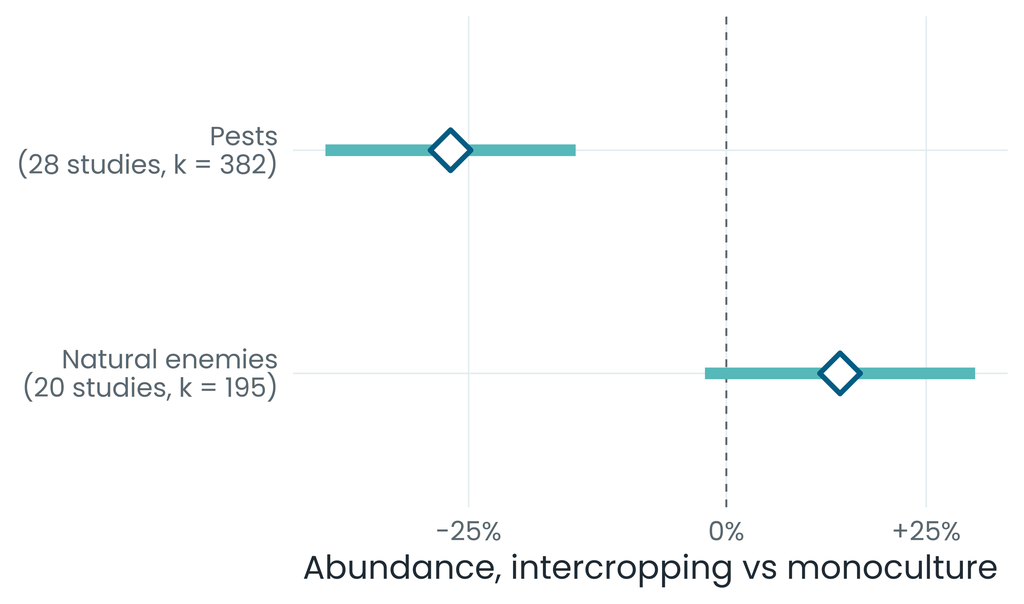

- Difference: pests -35% relative to natural enemies
- Omnibus test, cluster-robust: *F* = 20.4 on 1 and 10 df, *p* = 0.001
- Pseudo-R² ≈ **10%** (15% of within-study, 2% of between-study variance)

A clear moderator… that explains only **~10%** of the heterogeneity. Most of the variation remains unexplained.

## The groups, or the studies that measured them?

Your call

Studies on pests and studies on natural enemies may differ in crops, regions, designs… Can we trust the difference?

**Between-study** differences are **observational**: any study characteristic that travels with the moderator can **confound** it.

14 studies measured **both** groups. Split the moderator into its within- and between-study parts (`mods = ~ pest_w + pest_m`):  
**within studies: -36%** · between studies: -28% (*p* = 0.09).  
The within-study contrast — same fields, same year — is the stronger evidence.

## Meta-regression: the rules of the game

| Rule | Why |
| --- | --- |
| Choose moderators **a priori**, in the protocol | Testing many moderators guarantees false positives |
| **≈ 10 studies** (not rows) per moderator level or coefficient | A between-study moderator is tested on the number of **studies** (remember *df* ≈ 10 above): many rows per study add little |
| Report the **omnibus test**, coefficients **and** residual heterogeneity | “Significant” is not “explains the variation” |
| Beware **confounding** between moderators | Crops, regions and designs travel together |
| Prefer **within-study** contrasts when they exist | They control for study context |
| Moderator effects are **associations**, not causes | Studies were not randomised to moderator levels |

Source: Thompson and Higgins (2002); Nakagawa et al. (2023b); Borenstein et al. (2021), chap. 20–21.

# Missing data

## Missing SDs: check before you impute

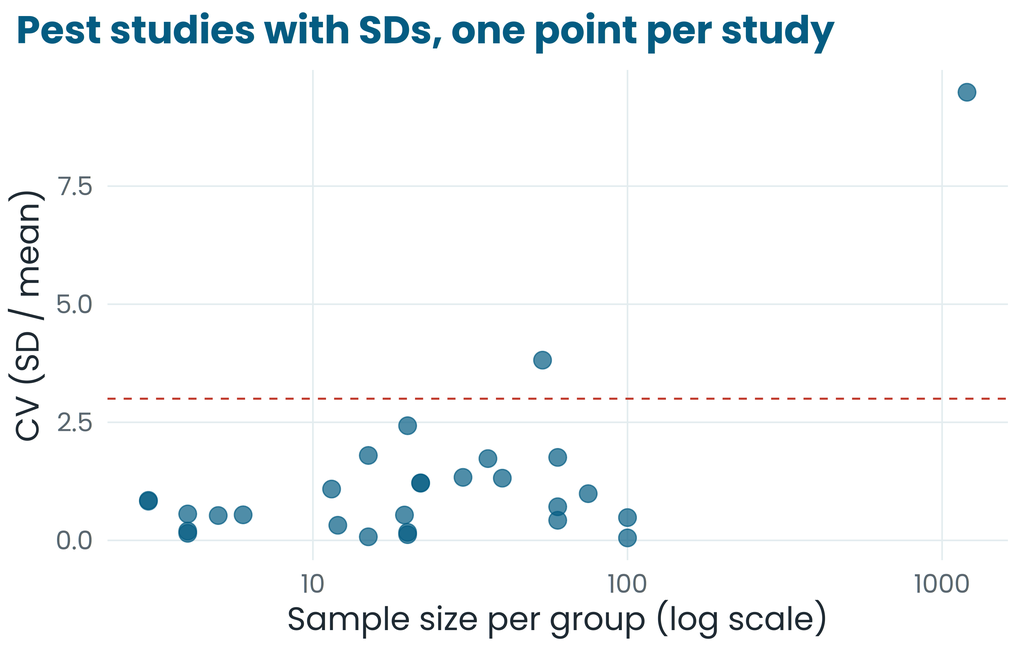

To impute a missing SD for lnRR, we borrow the **typical coefficient of variation** of the other studies (Nakagawa et al. 2023a).

First, look at the CVs: 2 studies stand out (CV > 3), one with *n* = 1,200 per group. Their SDs were **rebuilt as SE × √n**: if *n* counts subsamples rather than true replicates, both the SD and the precision are wrong. **Check the paper.**

## Missing SDs: impute, then compare

Pests (suspect studies set aside): 53 of 376 comparisons have no usable SD — 45 of them from **one** study.

**Why the CV?** The variance of lnRR is

$$v \approx \frac{SD_T^2}{n_T \bar{x}_T^2} + \frac{SD_C^2}{n_C \bar{x}_C^2} = \frac{CV_T^2}{n_T} + \frac{CV_C^2}{n_C}$$

So a missing SD only needs a **typical CV**, borrowed from the other studies:

$$v_{\text{imputed}} = \frac{\overline{CV}_T^{\,2}}{n_T} + \frac{\overline{CV}_C^{\,2}}{n_C}$$

$\overline{CV}$: mean CV weighted by *n*, per group [Nakagawa et al. (2023a); metafor `vtype = "AV"`]. The screening matters: squared mean CV = 0.21 without the suspect studies, 28 with them.

|  | Pest abundance [95% CI] |
| --- | --- |
| Complete cases (323) | -28% [-42; -11] |
| With imputed SDs (376) | -30% [-45; -11] |

Same conclusion — but most imputed rows come from one study, so do not over-generalise. Report **both**. Effect sizes: **recompute** them (from *t*, *p*, figures, medians), never fill them with averages.

# Beyond one comparison

## Network meta-analysis: comparing the never-compared

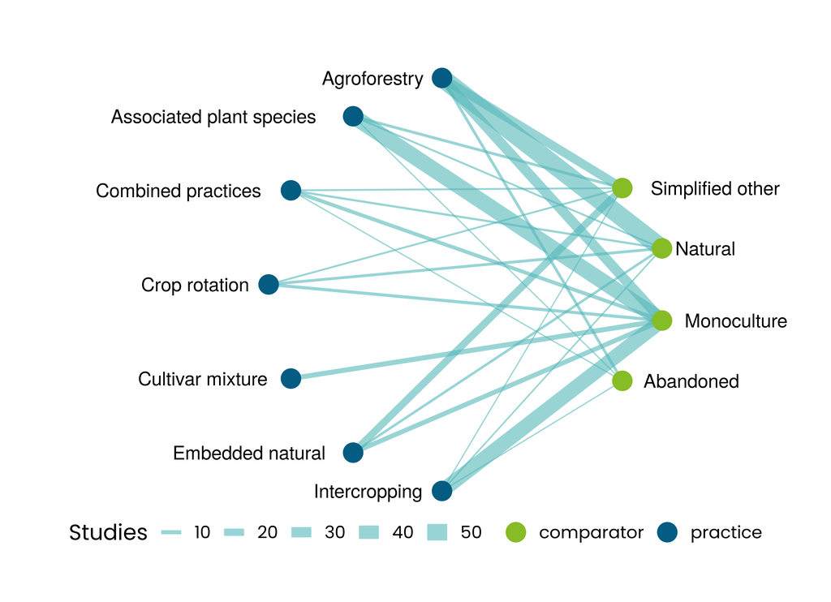

Intercropping or agroforestry: which is better? **Only 1 of 237 studies tested both.**

**Network meta-analysis** combines direct and **indirect** evidence (A vs C and B vs C → A vs B) to rank practices (Salanti 2012).

## Other tools you may meet

| Method | When | Keep in mind |
| --- | --- | --- |
| **Multivariate meta-analysis** | Several correlated outcomes (e.g. biodiversity **and** yield on the same plots) | Needs the within-study correlation — test a range (van Houwelingen et al. 2002) |
| **Selection models** | Sensitivity to publication bias | Need many studies; ignore dependence |
| **Random forests** (MetaForest) | Exploring many candidate moderators | Exploratory only; weight by precision; cross-validate **by study** |
| **Bayesian** meta-analysis | Few studies, informative priors, complex structures | Priors must be justified and tested |

## Practical · run, read, discuss — in pairs

| Time | Task | You… |
| --- | --- | --- |
| 16:33 | **Meta-regression**: pests vs natural enemies | fill **1 blank**, read *F*, coefficients, R² |
| 16:40 | **Within vs between** studies | fill **1 blank**, compare the two estimates |
| 16:47 | **Missing SDs**: CVs, impute, compare | run the given code, interpret |
| 16:55 | Debrief and wrap-up of the day (until 17:00) |  |

The script is **almost complete**: the work is **reading the outputs**, not writing code. Questions to discuss are in the script (`# Q:`). Open **`meta_analysis_course.Rproj`** (the course kit), then **`td_advanced.R`**; folded answers on the practical web page.

## Key messages

1. Meta-regression tests whether a moderator **explains** heterogeneity; report the omnibus test, coefficients **and** what remains unexplained.
2. Between-study moderators are **associations**; within-study contrasts are stronger.
3. Missing SDs: **check CVs**, impute transparently, show results **with and without**.
4. Advanced methods (network, multivariate, machine learning) answer specific questions — they do not rescue weak data.

## In the online notebook

Each point of this session developed further, with the same data, more pitfalls and exercises with solutions:

- [Moderators, missing data and networks](https://literaturesynthesis.github.io/notebook/chapters/heterogeneity-moderators.html)
- [Certainty of evidence and what can be inferred](https://literaturesynthesis.github.io/notebook/chapters/certainty.html)
- [Your turn: soil carbon under agroforestry (end-to-end exercise)](https://literaturesynthesis.github.io/notebook/chapters/your-turn.html)
- [Before you submit: a checklist](https://literaturesynthesis.github.io/notebook/chapters/checklist.html)

**literaturesynthesis.github.io/notebook**

## References

Borenstein, M., L. V. Hedges, J. P. T. Higgins, and H. R. Rothstein. 2021. Introduction to meta-analysis. Second edition. Wiley, Chichester.

Nakagawa, S., D. W. A. Noble, M. Lagisz, R. Spake, W. Viechtbauer, and A. M. Senior. 2023a. [A robust and readily implementable method for the meta-analysis of response ratios with and without missing standard deviations](https://doi.org/10.1111/ele.14144). Ecology Letters 26:232–244.

Nakagawa, S., Y. Yang, E. L. Macartney, R. Spake, and M. Lagisz. 2023b. [Quantitative evidence synthesis: A practical guide on meta-analysis, meta-regression, and publication bias tests for environmental sciences](https://doi.org/10.1186/s13750-023-00301-6). Environmental Evidence 12:8.

Salanti, G. 2012. [Indirect and mixed-treatment comparison, network, or multiple-treatments meta-analysis: Many names, many benefits, many concerns for the next generation evidence synthesis tool](https://doi.org/10.1002/jrsm.1037). Research Synthesis Methods 3:80–97.

Thompson, S. G., and J. P. T. Higgins. 2002. [How should meta-regression analyses be undertaken and interpreted?](https://doi.org/10.1002/sim.1187) Statistics in Medicine 21:1559–1573.

van Houwelingen, H. C., L. R. Arends, and T. Stijnen. 2002. [Advanced methods in meta-analysis: Multivariate approach and meta-regression](https://doi.org/10.1002/sim.1040). Statistics in Medicine 21:589–624.